# ReMoTe simulation: No mixing, no Ackley

10 May, 2022, 13:51

## Background

We initialize a population of size one million using the ARI, and age structure that mimics South Africa. We then generate new case of disease over a one year period and explore the role of reinfection in generating new cases of disease. We simulate populations with prevalence ranging from 100/100k to 1000/100k.

We use the correction in our calculations that true prevalence should be 1.66 times reported to account for smear negative TB.

We explore varying two main parameters: 1. The risk of progression to disease as a function of the number of infections. 2. The proportion of the population that is at high risk of infection.

## Parameters used in this simulation

### Risk of progression to disease

Following is a depiction of the parameters used for the risk of progression to disease for those with a new infection as a function of the number of total infections.

Here, the risk of progression with one infection is 0.05 and the risk with two infections is 0.02. After two infections the risk increases by 0 with each infection.

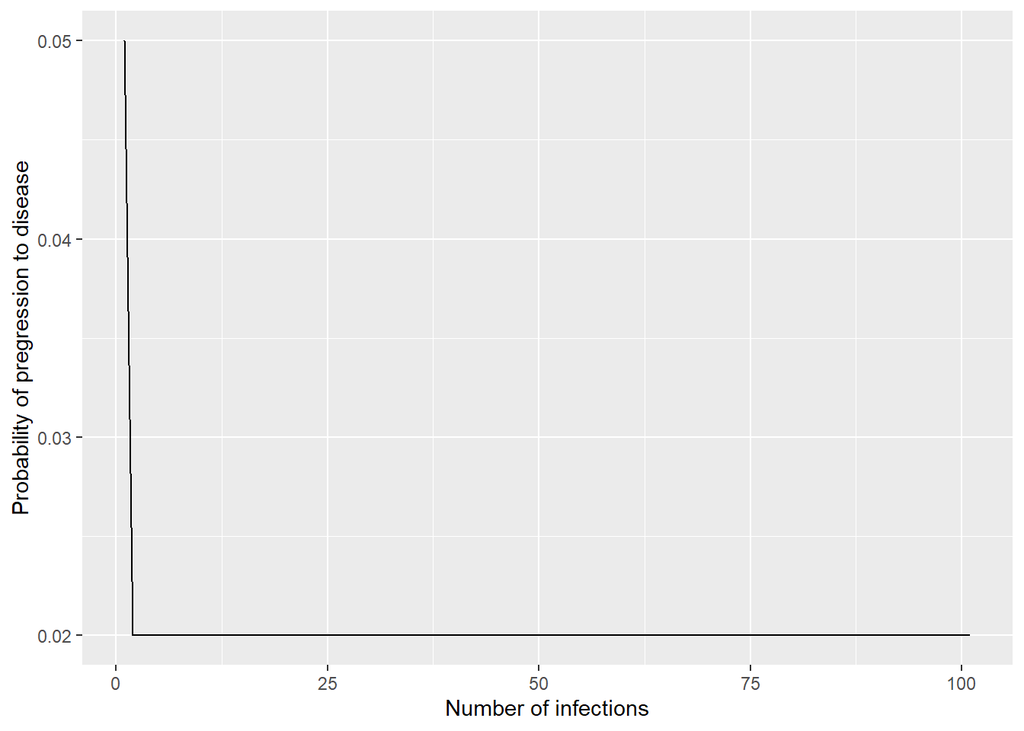

### Proportion of the population at high risk

In this simulation, we assume that 1 proportion of the population are at low risk of infection.

In summary the parameters for the simulation are:

| Prev(per100k) | Overall ARI | Population Low Risk | Prob progress with 1 infection | Probability with 2 infections | increase per addt’l infection |
| --- | --- | --- | --- | --- | --- |
| 100 | 0.90 | 1 | 0.05 | 0.02 | 0 |
| 200 | 1.27 | 1 | 0.05 | 0.02 | 0 |
| 300 | 1.63 | 1 | 0.05 | 0.02 | 0 |
| 400 | 2.00 | 1 | 0.05 | 0.02 | 0 |
| 500 | 2.36 | 1 | 0.05 | 0.02 | 0 |
| 600 | 2.72 | 1 | 0.05 | 0.02 | 0 |
| 700 | 3.10 | 1 | 0.05 | 0.02 | 0 |
| 800 | 3.46 | 1 | 0.05 | 0.02 | 0 |
| 900 | 3.83 | 1 | 0.05 | 0.02 | 0 |
| 1000 | 4.20 | 1 | 0.05 | 0.02 | 0 |

## Parameter sweep to determine ARI

We do not need to do a parameter sweep, since there is no mixing in this scenario.

## Initializing the population

We first determine the number of infections that individuals have at the start of the simulation.

### Results of initialized population

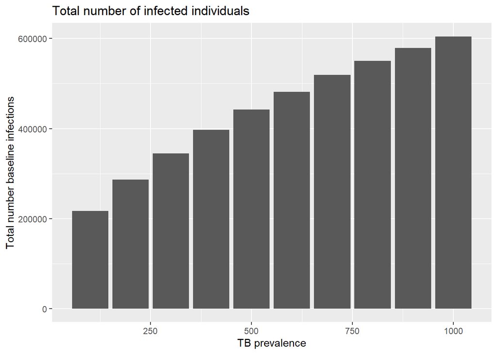

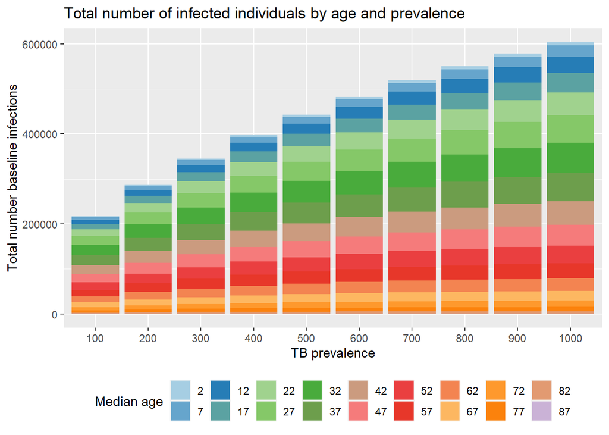

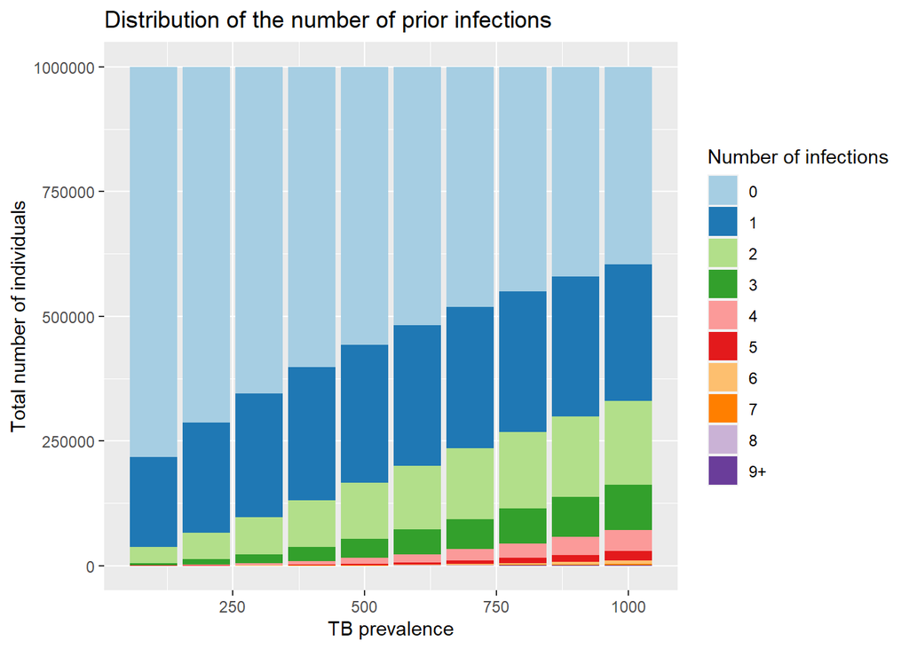

We focus in on those with at least six prior infections in this plot.

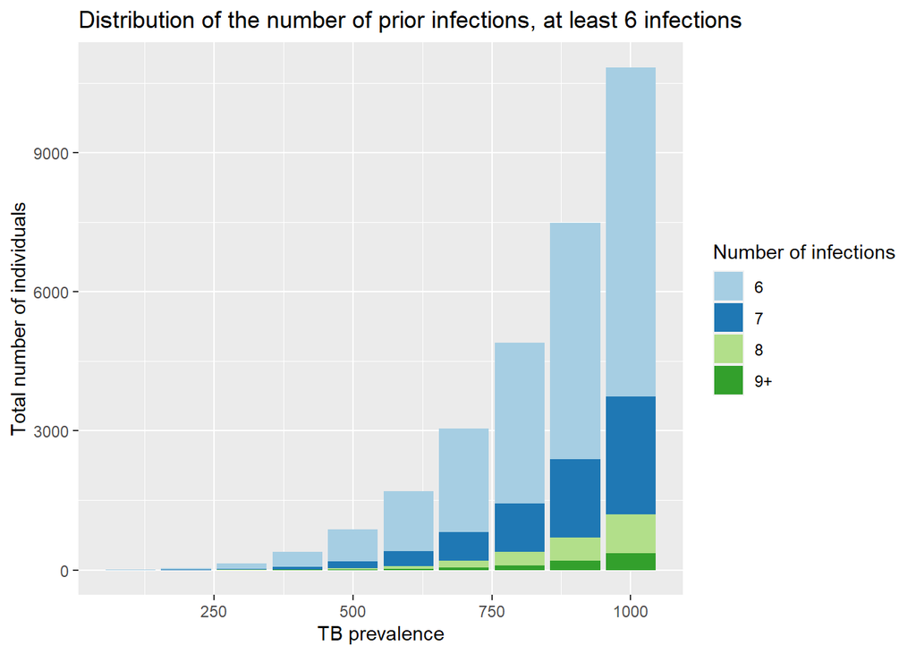

We show the prevalence of LTBI by age and TB disease prevalence. This can be compared to the Dodd et al data.

Prevalence of LTBI by age and TB prevalence

|  | Prev100 | Prev200 | Prev300 | Prev400 | Prev500 | Prev600 | Prev700 | Prev800 | Prev900 | Prev1000 |
| --- | --- | --- | --- | --- | --- | --- | --- | --- | --- | --- |
| 0-4 | 0.02 | 0.03 | 0.03 | 0.04 | 0.05 | 0.05 | 0.06 | 0.07 | 0.07 | 0.08 |
| 5-9 | 0.06 | 0.09 | 0.11 | 0.13 | 0.15 | 0.17 | 0.20 | 0.22 | 0.24 | 0.25 |
| 10-14 | 0.10 | 0.14 | 0.18 | 0.21 | 0.25 | 0.28 | 0.31 | 0.34 | 0.37 | 0.40 |
| 15-19 | 0.14 | 0.19 | 0.24 | 0.29 | 0.33 | 0.37 | 0.41 | 0.44 | 0.48 | 0.51 |
| 20-24 | 0.18 | 0.24 | 0.30 | 0.36 | 0.41 | 0.45 | 0.49 | 0.53 | 0.57 | 0.60 |
| 25-29 | 0.22 | 0.29 | 0.36 | 0.42 | 0.47 | 0.52 | 0.57 | 0.61 | 0.64 | 0.68 |
| 30-34 | 0.25 | 0.33 | 0.41 | 0.47 | 0.53 | 0.58 | 0.63 | 0.67 | 0.71 | 0.74 |
| 35-39 | 0.28 | 0.37 | 0.45 | 0.52 | 0.58 | 0.63 | 0.68 | 0.72 | 0.76 | 0.79 |
| 40-44 | 0.31 | 0.41 | 0.50 | 0.57 | 0.63 | 0.68 | 0.73 | 0.77 | 0.80 | 0.83 |
| 45-49 | 0.34 | 0.45 | 0.54 | 0.61 | 0.67 | 0.72 | 0.77 | 0.80 | 0.83 | 0.86 |
| 50-54 | 0.37 | 0.48 | 0.57 | 0.65 | 0.71 | 0.76 | 0.80 | 0.83 | 0.86 | 0.89 |
| 55-59 | 0.40 | 0.52 | 0.61 | 0.68 | 0.74 | 0.79 | 0.83 | 0.86 | 0.89 | 0.91 |
| 60-64 | 0.43 | 0.54 | 0.64 | 0.71 | 0.77 | 0.81 | 0.85 | 0.88 | 0.91 | 0.93 |
| 65-69 | 0.45 | 0.57 | 0.66 | 0.74 | 0.79 | 0.84 | 0.87 | 0.90 | 0.92 | 0.94 |
| 70-74 | 0.48 | 0.60 | 0.69 | 0.76 | 0.82 | 0.86 | 0.89 | 0.92 | 0.94 | 0.95 |
| 75-79 | 0.50 | 0.62 | 0.71 | 0.79 | 0.84 | 0.88 | 0.91 | 0.93 | 0.95 | 0.96 |
| 80-84 | 0.52 | 0.65 | 0.74 | 0.81 | 0.86 | 0.89 | 0.92 | 0.94 | 0.96 | 0.97 |
| 85+ | 0.54 | 0.67 | 0.76 | 0.82 | 0.87 | 0.91 | 0.93 | 0.95 | 0.96 | 0.97 |

## New cases generated over one year

We now generate cases over a one year period. All infected individuals with no reinfection in this year have a 0.00075 probability of progressing to active disease. Individuals with a first infection have a 0.05 probability of progressing. Those with a new re-infection follow the probability of progressing determined by Ackley, which increases linearly from 0.02 by a step of 0 until it reaches 1.

We can calculate the following statistics:

- Cases from old infection (all in high risk)
- Total cases
- percent cases from first infection
- percent cases from old infection
- Corrected prevalence (=1.66*smear positive prevalence)
- Incidence (per 100000)
- Implied duration (=prev/Inc)
- Reproductive number for infection (= #new infections/corrected prevalence)
- Reproductive number for disease (= #ATB from new infections/corrected prevalence)

We also look at:

- Uninfected individuals at start of simulation
- Number infected during one year
- Observed ARI

| ATB from old infections | Total ATB | percent first inf | percent old inf | corrected prevalence | incidence (per 100,000) | duration | Rt infections | Rt disease |
| --- | --- | --- | --- | --- | --- | --- | --- | --- |
| 156.1009 | 547.4745 | 0.6434810 | 0.2851290 | 166 | 54.74745 | 3.032104 | 54.21687 | 2.3576727 |
| 205.1137 | 731.0772 | 0.6200064 | 0.2805636 | 332 | 73.10772 | 4.541244 | 38.25301 | 1.5842275 |
| 246.2905 | 892.7384 | 0.5982489 | 0.2758821 | 498 | 89.27384 | 5.578342 | 32.73092 | 1.2980880 |
| 282.9589 | 1044.5917 | 0.5769924 | 0.2708799 | 664 | 104.45917 | 6.356550 | 30.12048 | 1.1470375 |
| 313.9658 | 1180.8733 | 0.5573665 | 0.2658759 | 830 | 118.08733 | 7.028697 | 28.43373 | 1.0444668 |
| 341.0458 | 1307.7926 | 0.5387537 | 0.2607798 | 996 | 130.77926 | 7.615886 | 27.30923 | 0.9706293 |
| 365.9894 | 1433.3325 | 0.5201667 | 0.2553416 | 1162 | 143.33325 | 8.106982 | 26.67814 | 0.9185396 |
| 386.6610 | 1545.6073 | 0.5035198 | 0.2501677 | 1328 | 154.56073 | 8.592092 | 26.05422 | 0.8727005 |
| 405.3268 | 1655.3594 | 0.4873389 | 0.2448573 | 1494 | 165.53594 | 9.025230 | 25.63588 | 0.8367019 |
| 421.7316 | 1760.3023 | 0.4720503 | 0.2395791 | 1660 | 176.03023 | 9.430198 | 25.30120 | 0.8063679 |

### Plotting the results

We show the number of TB disease cases by prevalence and source (old infection, new primary infection, re-infection).

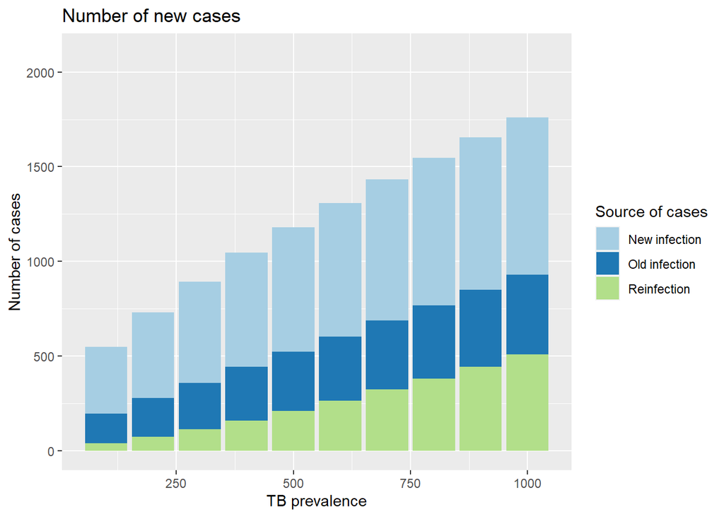